# INTRODUCTION OF DATASET

# Multivariate Analysis

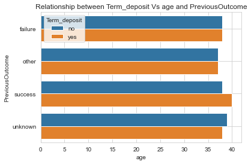

```python
sns.barplot(x = 'age',
            y = 'PreviousOutcome',
            hue = 'Term_deposit',
            data = bm,
            estimator = np.median,
            ci = 0)

plt.title("Relationship between Term_deposit Vs age and PreviousOutcome")
plt.xlabel('age')
plt.ylabel('PreviousOutcome')
plt.grid(True)
# To show the plot
plt.show()
```

**Explanation:**

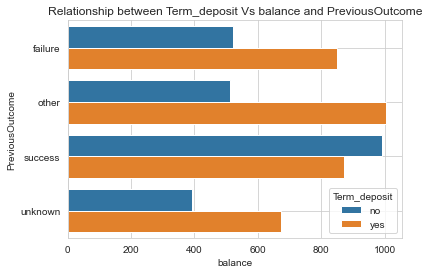

```python
sns.barplot(x = 'balance',
            y = 'PreviousOutcome',
            hue = 'Term_deposit',
            data = bm,
            estimator = np.median,
            ci = 0)

plt.title("Relationship between Term_deposit Vs balance and PreviousOutcome")
plt.xlabel('balance')
plt.ylabel('PreviousOutcome')
plt.grid(True)
# To show the plot
plt.show()
```

**Explanation:**

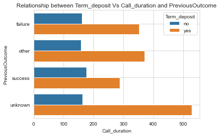

```python
sns.barplot(x = 'Call_duration',
            y = 'PreviousOutcome',
            hue = 'Term_deposit',
            data = bm,
            estimator = np.median,
            ci = 0)

plt.title("Relationship between Term_deposit Vs Call_duration and PreviousOutcome")
plt.xlabel('Call_duration')
plt.ylabel('PreviousOutcome')
plt.grid(True)
# To show the plot
plt.show()
```

**Explanation:**

Bar plot depicts ratio of success possibility of previous Outcome campaign somewhere near to 4.5 minutes on an average

Age is positively skewed towards right so lets do some analysis with help of histogram

# Treating Skewness

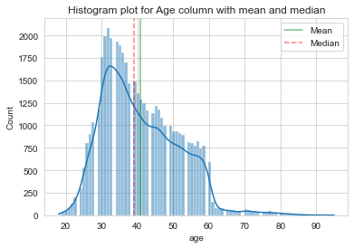

```python
sns.histplot(data = bm['age'], kde = True) # Histogram plot using seaborn
plt.axvline(x=bm.age.mean(),color='green',alpha=0.5,label='Mean') # mean hue
plt.axvline(x=bm.age.median(),c='red',ls='--',alpha=0.5,label='Median') # median hue
plt.legend()
plt.title("Histogram plot for Age column with mean and median")
```

**Explanation:**

If we observe the curve, it is skewed towards right and mean is greater than median

Selected Cube root transformation as log and square root transformations not plotting as normal distribution.

*Cube Root Transformation*

```python
# Cube root transformation
bm['age'] = np.cbrt(bm['age'])
```

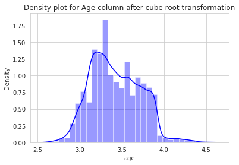

```python
sns.distplot(bm['age'], kde = True, color ='blue', bins = 30) # Density Plot for Age factor
plt.title("Density plot for Age column after cube root transformation")
```